신록예찬's 블로그

# (노트) ggplot2- Arranging plots

Jan 10, 2022 • 신록예찬 • 5 min read

R

- imports
- 기본사용법
- 연산자
- layout
- modifying subplots
- super-title, sub-title, annotation
  - sub-title
- plot 삽입

### imports

```r
library(tidyverse)
library(patchwork)
```

### 기본사용법

`-` p1~p4 정의

```r
p1 <- ggplot(mpg) +
  geom_point(aes(x = displ, y = hwy))

p2 <- ggplot(mpg) +
  geom_bar(aes(x = as.character(year), fill = drv), position = "dodge") +
  labs(x = "year")

p3 <- ggplot(mpg) +
  geom_density(aes(x = hwy, fill = drv), colour = NA) +
  facet_grid(rows = vars(drv))

p4 <- ggplot(mpg) +
  stat_summary(aes(x = drv, y = hwy, fill = drv), geom = "col", fun.data = mean_se) +
  stat_summary(aes(x = drv, y = hwy), geom = "errorbar", fun.data = mean_se, width = 0.5)
```

`-` p1과 p2를 합침

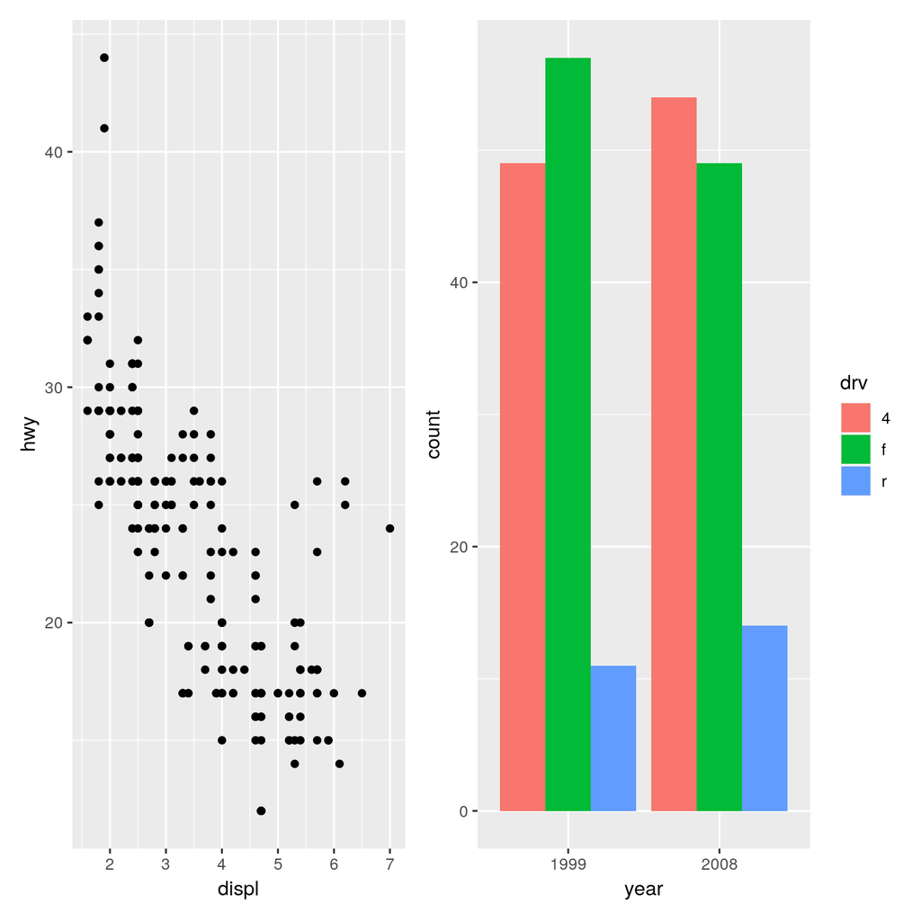

```r
p1+p2
```

`-` p1~p4를 합침

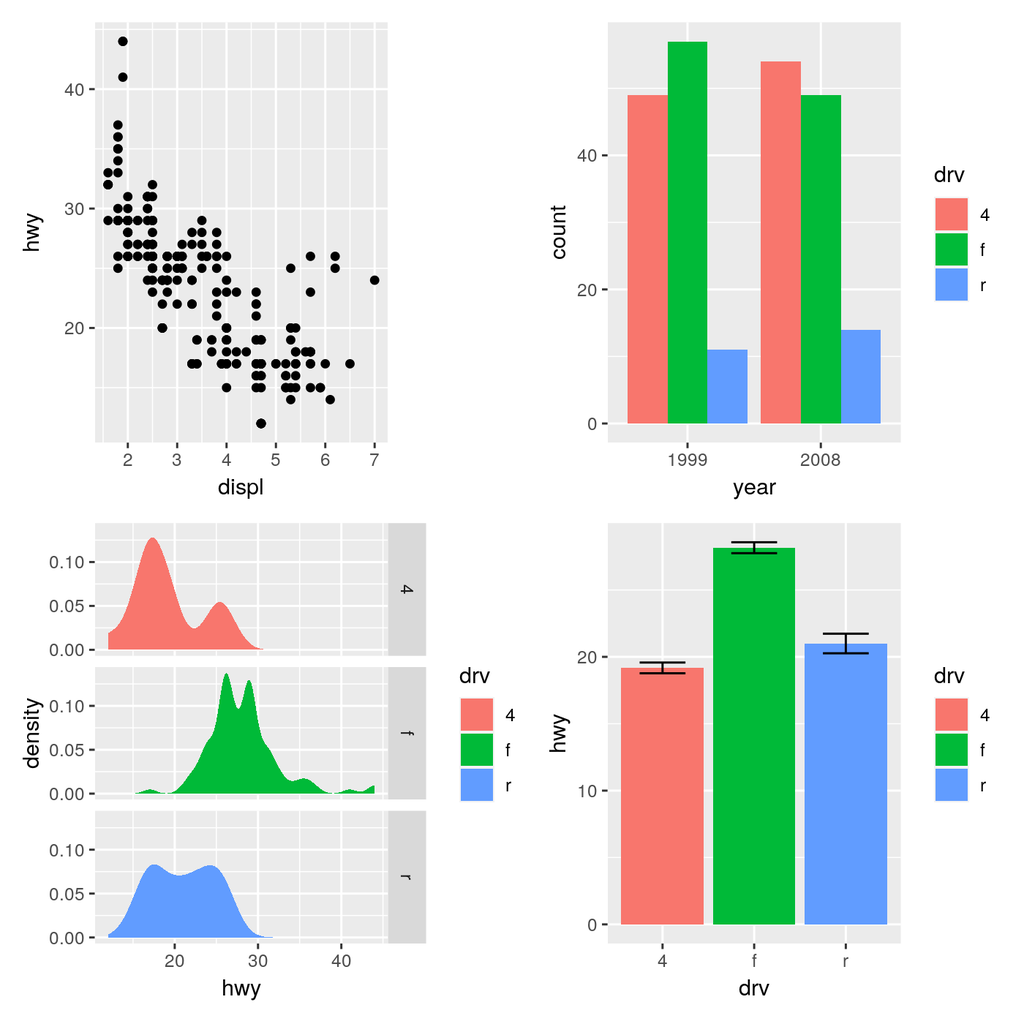

```r
p1+p2+p3+p4
```

### 연산자

`-` p1~p4 정의

```r
p1 <- ggplot(mpg) +
  geom_point(aes(x = displ, y = hwy))

p2 <- ggplot(mpg) +
  geom_bar(aes(x = as.character(year), fill = drv), position = "dodge") +
  labs(x = "year")

p3 <- ggplot(mpg) +
  geom_density(aes(x = hwy, fill = drv), colour = NA) +
  facet_grid(rows = vars(drv))

p4 <- ggplot(mpg) +
  stat_summary(aes(x = drv, y = hwy, fill = drv), geom = "col", fun.data = mean_se) +
  stat_summary(aes(x = drv, y = hwy), geom = "errorbar", fun.data = mean_se, width = 0.5)
```

`-` p1, p2 를 위아래로 합침

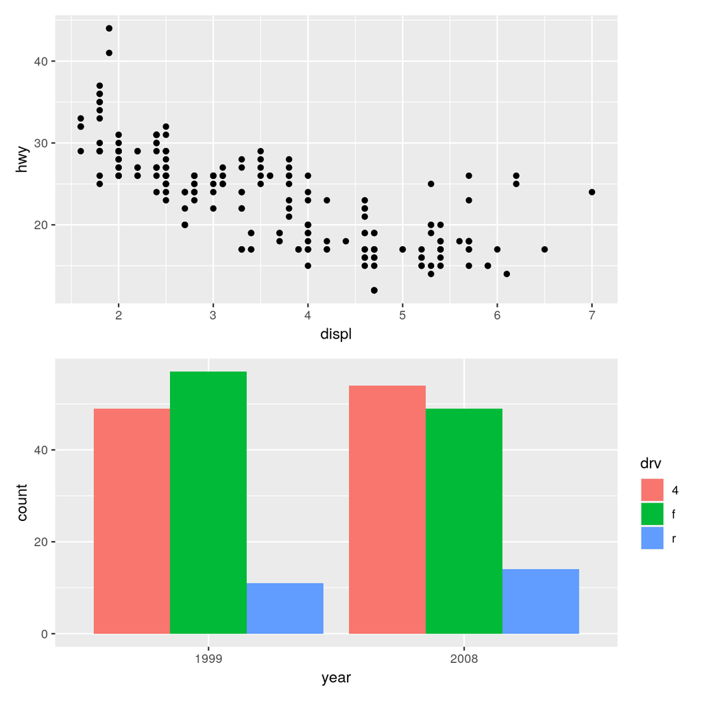

```r
p1 / p2
```

`-` p1, p2를 좌우로 합침

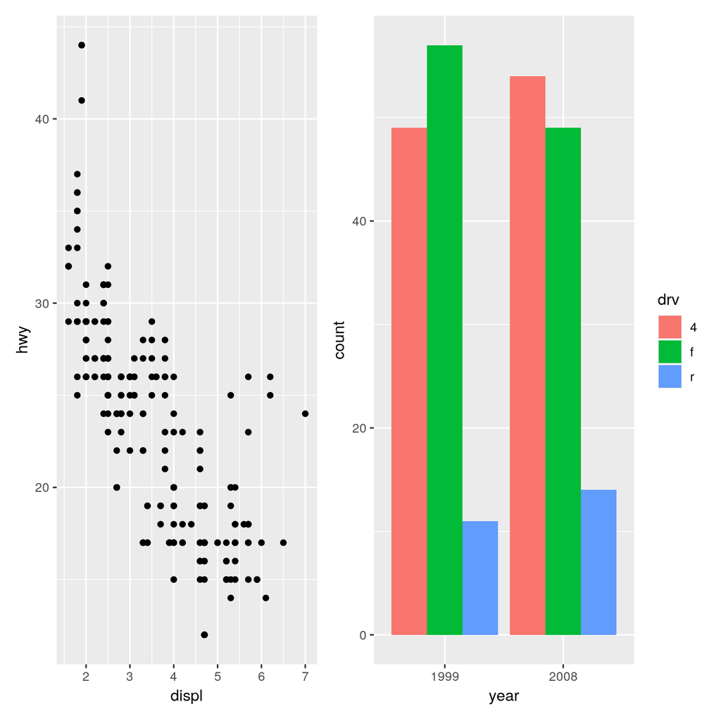

```r
p1 | p2
```

`-` 다양한 응용가능 1

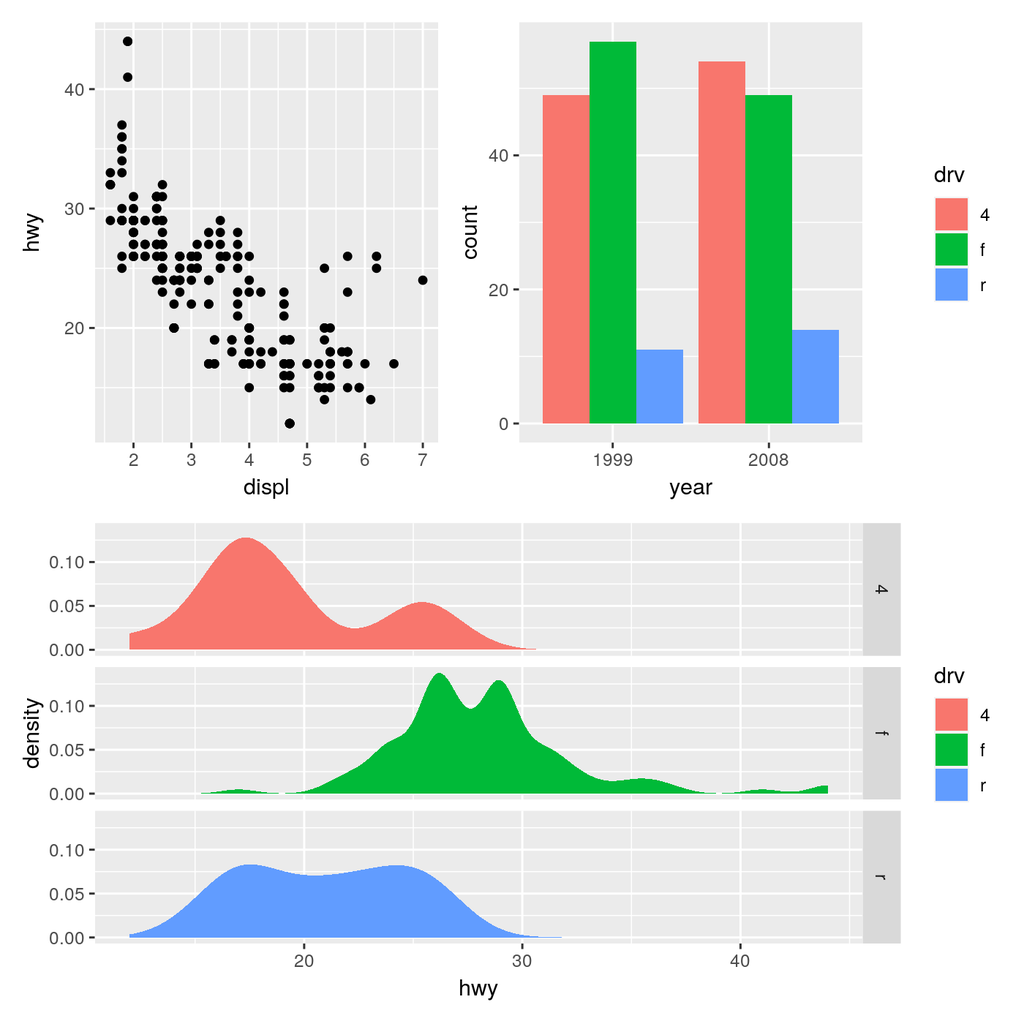

```r
(p1 | p2) / p3
```

`-` 다양한 응용가능 2

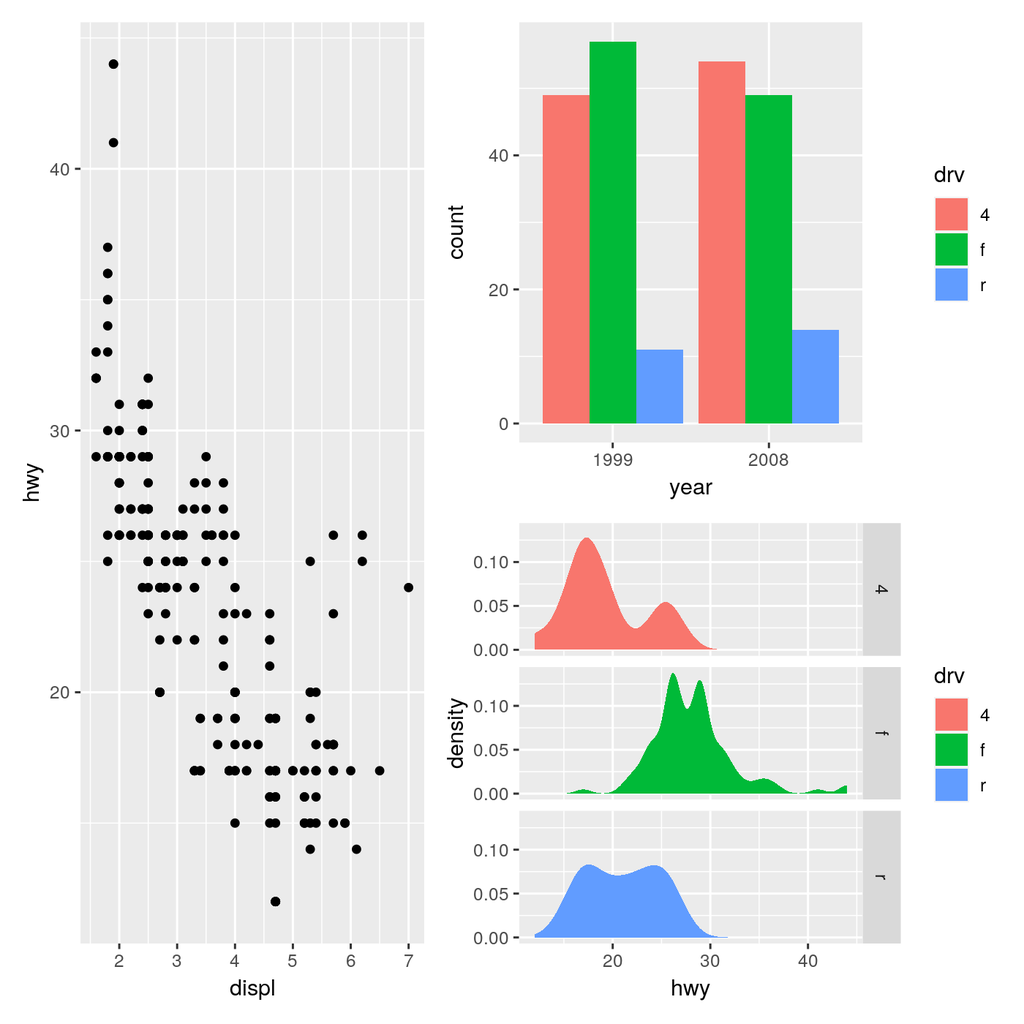

```r
p1 | (p2 / p3)
```

`-` 다양한 응용가능 3

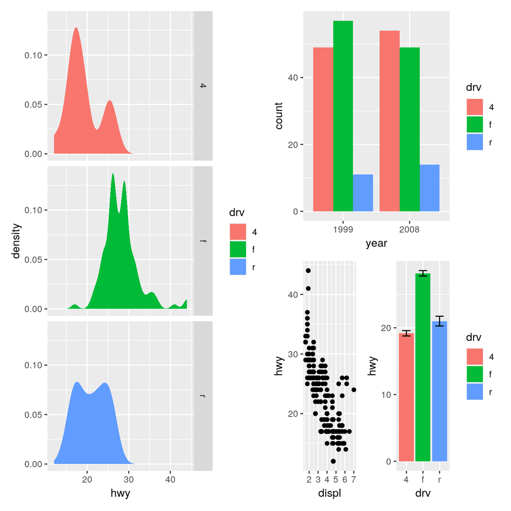

```r
p3 | (p2 / (p1|p4))
```

### layout

`-` p1~p4 정의

```r
p1 <- ggplot(mpg) +
  geom_point(aes(x = displ, y = hwy, color = class))

p2 <- ggplot(mpg) +
  geom_bar(aes(x = as.character(year), fill = drv), position = "dodge") +
  labs(x = "year")

p3 <- ggplot(mpg) +
  geom_density(aes(x = hwy, fill = drv), colour = NA) +
  facet_grid(rows = vars(drv))

p4 <- ggplot(mpg) +
  stat_summary(aes(x = drv, y = hwy, fill = drv), geom = "col", fun.data = mean_se) +
  stat_summary(aes(x = drv, y = hwy), geom = "errorbar", fun.data = mean_se, width = 0.5)
```

```r
p1 + p2 + p3 + plot_layout(ncol = 2)
```

[output not shown]

`-` 범례 가이드를 한쪽으로 정리하고 싶다면?

```r
p1 + p2 + p3 + plot_layout(ncol = 2)
```

[output not shown]

```r
p1 + p2 + p3 + plot_layout(ncol = 2)
```

[output not shown]

(step2) 가이드를 모음

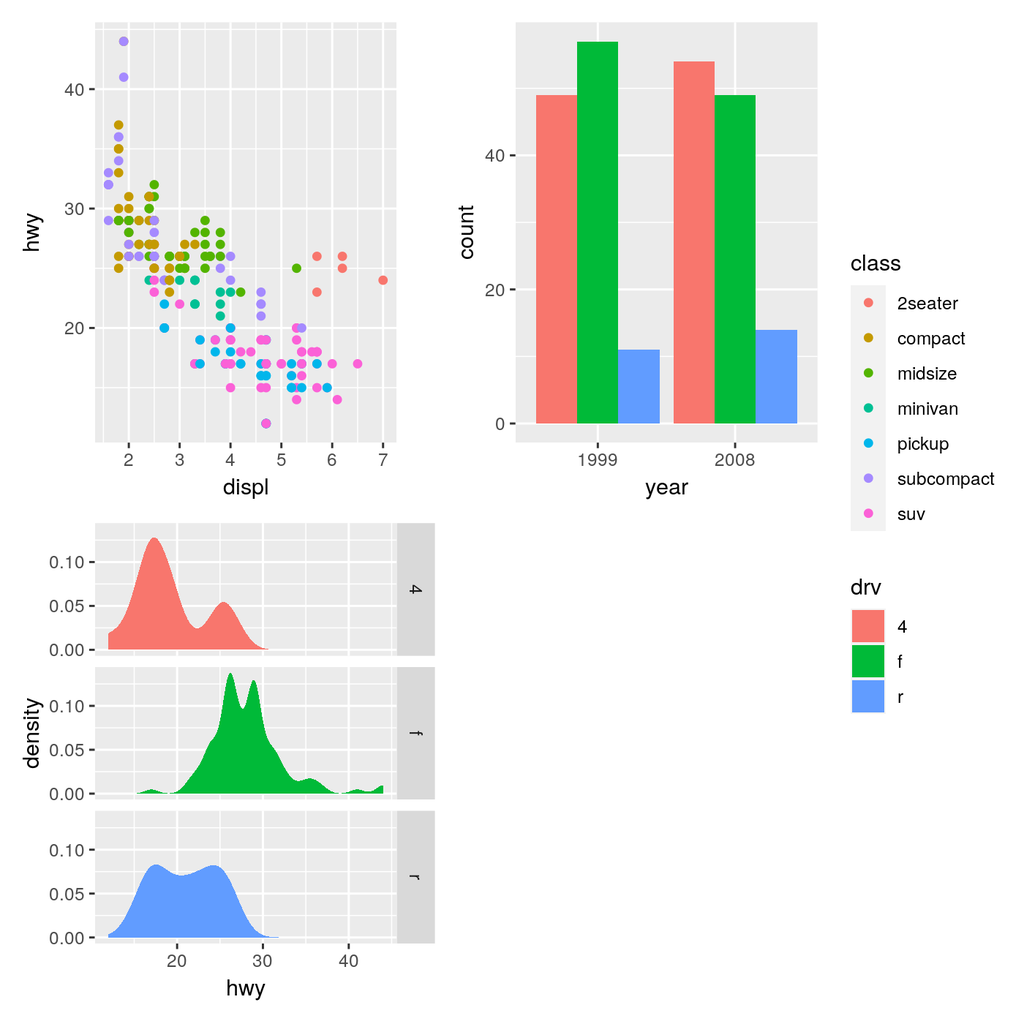

```r
p1 + p2 + p3 + plot_layout(ncol = 2, guides="collect")
```

(step3) 가이드에어리어를 따로 만들어줌

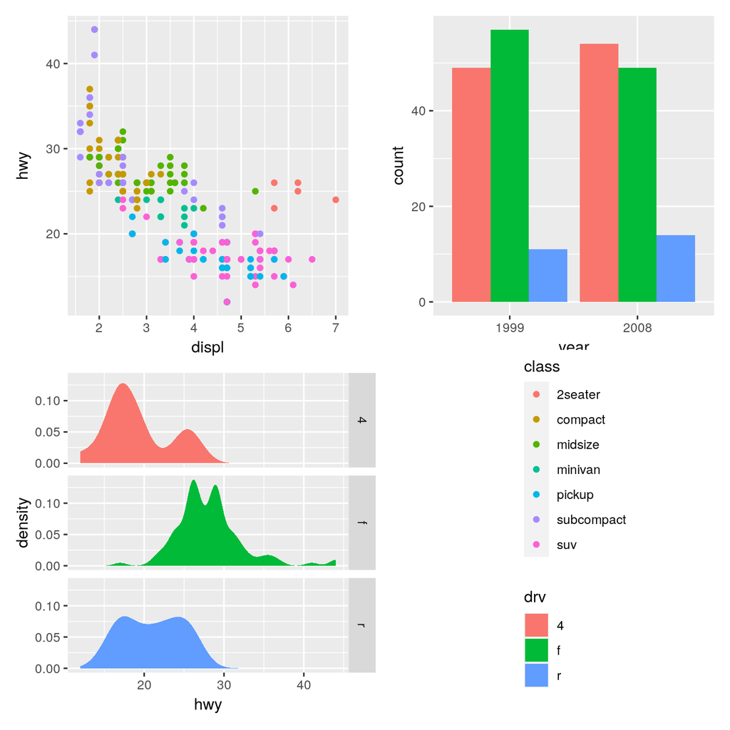

```r
p1 + p2 + p3 + guide_area()+plot_layout(ncol = 2, guides="collect")
```

### modifying subplots

`-` p1~p4 정의

```r
p1 <- ggplot(mpg) +
  geom_point(aes(x = displ, y = hwy, color = class))

p2 <- ggplot(mpg) +
  geom_bar(aes(x = as.character(year), fill = drv), position = "dodge") +
  labs(x = "year")

p3 <- ggplot(mpg) +
  geom_density(aes(x = hwy, fill = drv), colour = NA) +
  facet_grid(rows = vars(drv))

p4 <- ggplot(mpg) +
  stat_summary(aes(x = drv, y = hwy, fill = drv), geom = "col", fun.data = mean_se) +
  stat_summary(aes(x = drv, y = hwy), geom = "errorbar", fun.data = mean_se, width = 0.5)
```

`-` 첫번째 그림 테마 변경

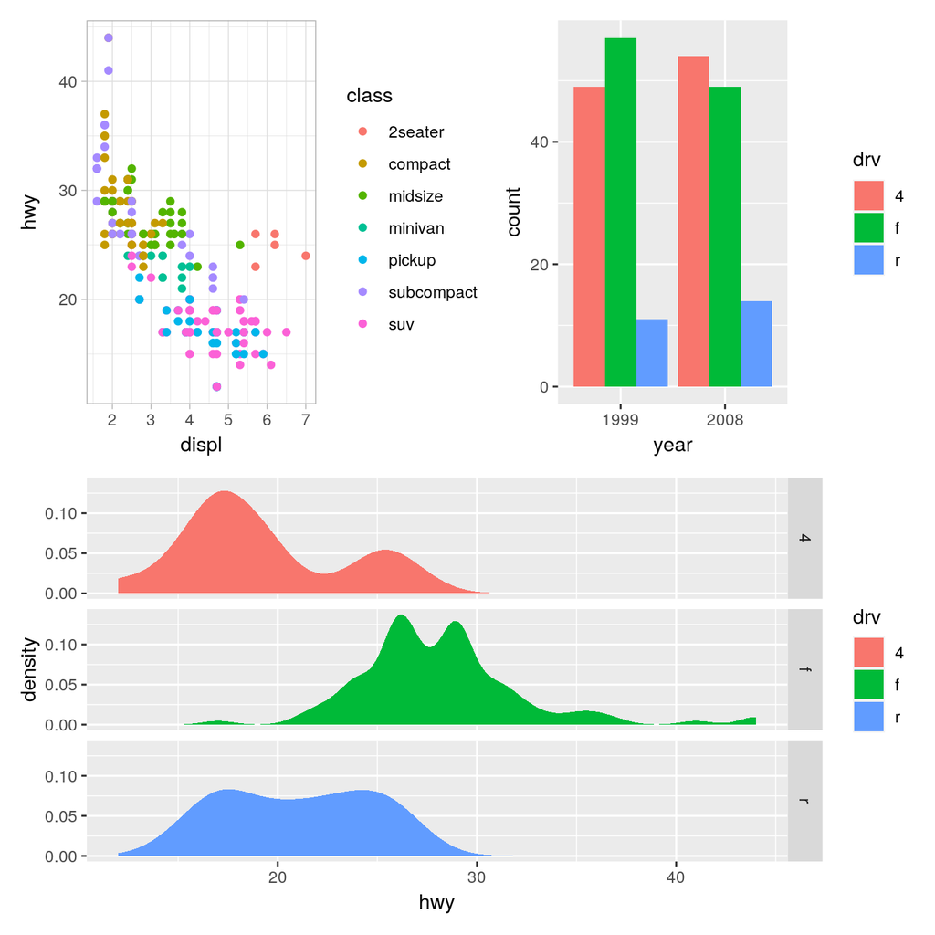

```r
p <- (p1 + p2) / p3
p[[1]][[1]] <- p[[1]][[1]] + theme_light()
p
```

`-` 두번째 그림 테마변경

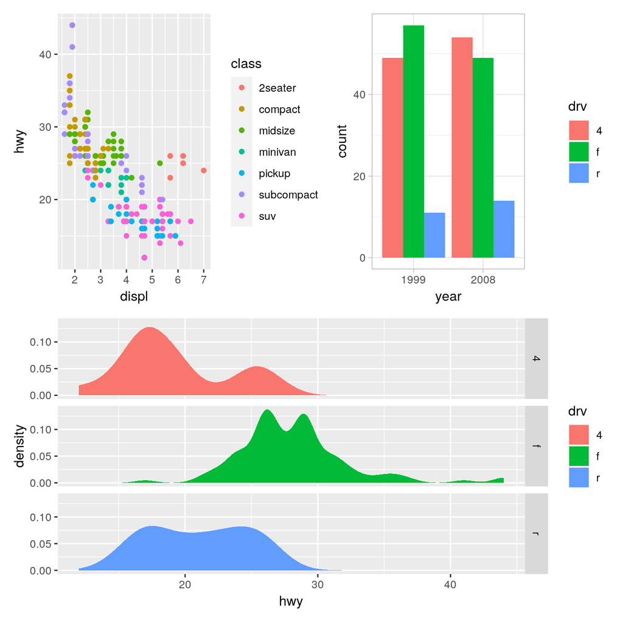

```r
p <- (p1 + p2) / p3
p[[1]][[2]] <- p[[1]][[2]] + theme_light()
p
```

`-` 세번째 그림 테마변경

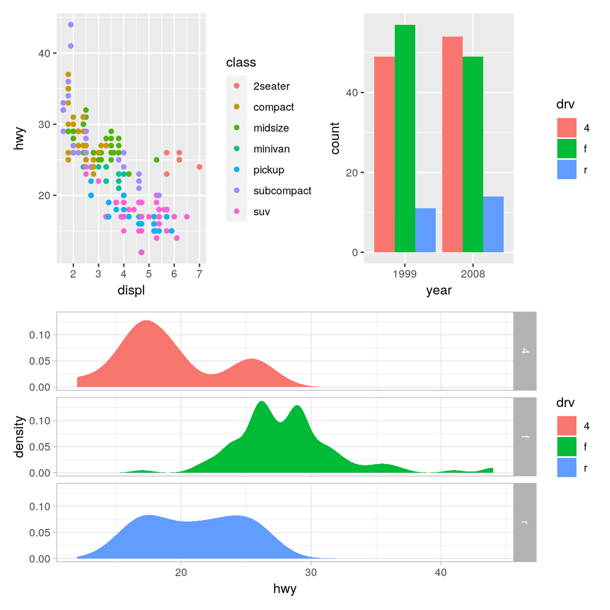

```r
p <- (p1 + p2) / p3
p[[2]] <- p[[2]] + theme_light()
p
```

```r
p <- (p1 + p2) / p3
p & theme_minimal()
```

[output not shown]

[output not shown]

`-` 모든서브플랏의 y축범위변경

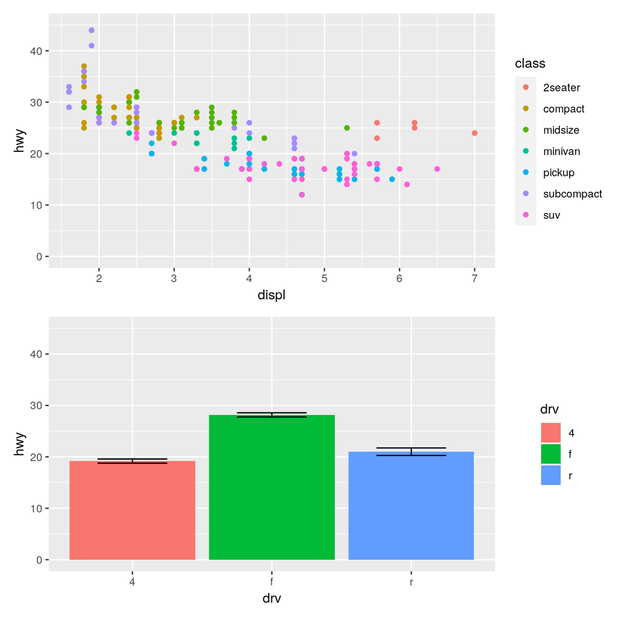

```r
p = p1 / p4
p & scale_y_continuous(limits = c(0, 45))
```

### super-title, sub-title, annotation

`-` p1~p4 정의

```r
p1 <- ggplot(mpg) +
  geom_point(aes(x = displ, y = hwy, color = class))

p2 <- ggplot(mpg) +
  geom_bar(aes(x = as.character(year), fill = drv), position = "dodge") +
  labs(x = "year")

p3 <- ggplot(mpg) +
  geom_density(aes(x = hwy, fill = drv), colour = NA) +
  facet_grid(rows = vars(drv))

p4 <- ggplot(mpg) +
  stat_summary(aes(x = drv, y = hwy, fill = drv), geom = "col", fun.data = mean_se) +
  stat_summary(aes(x = drv, y = hwy), geom = "errorbar", fun.data = mean_se, width = 0.5)
```

`-` supertitle, annotation

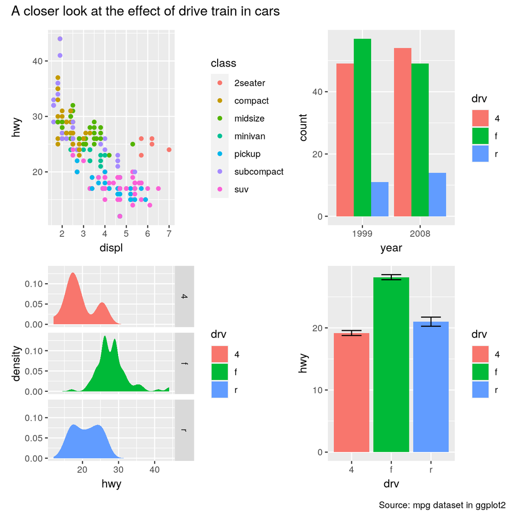

```r
p <- p1 + p2 + p3 + p4 + plot_annotation(
  title = "A closer look at the effect of drive train in cars",
  caption = "Source: mpg dataset in ggplot2"
)
p
```

`-` 글씨체변경 (1)

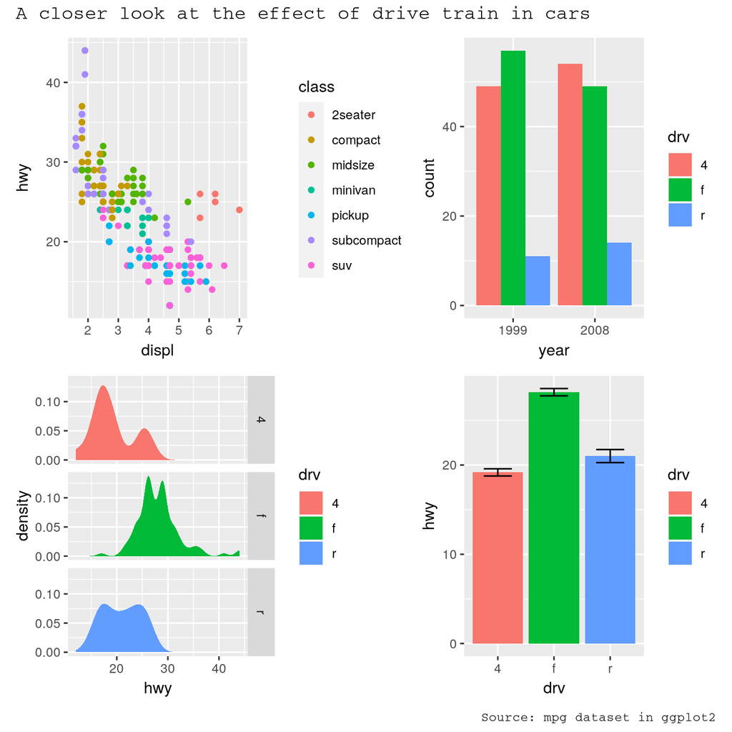

```r
p <- p1 + p2 + p3 + p4 + plot_annotation(
  title = "A closer look at the effect of drive train in cars",
  caption = "Source: mpg dataset in ggplot2",
  theme = theme_gray(base_family = "mono")  ### 이걸 추가하면 글씨체가 바뀐다.
)
p
```

`-` 글씨체변경 (2)

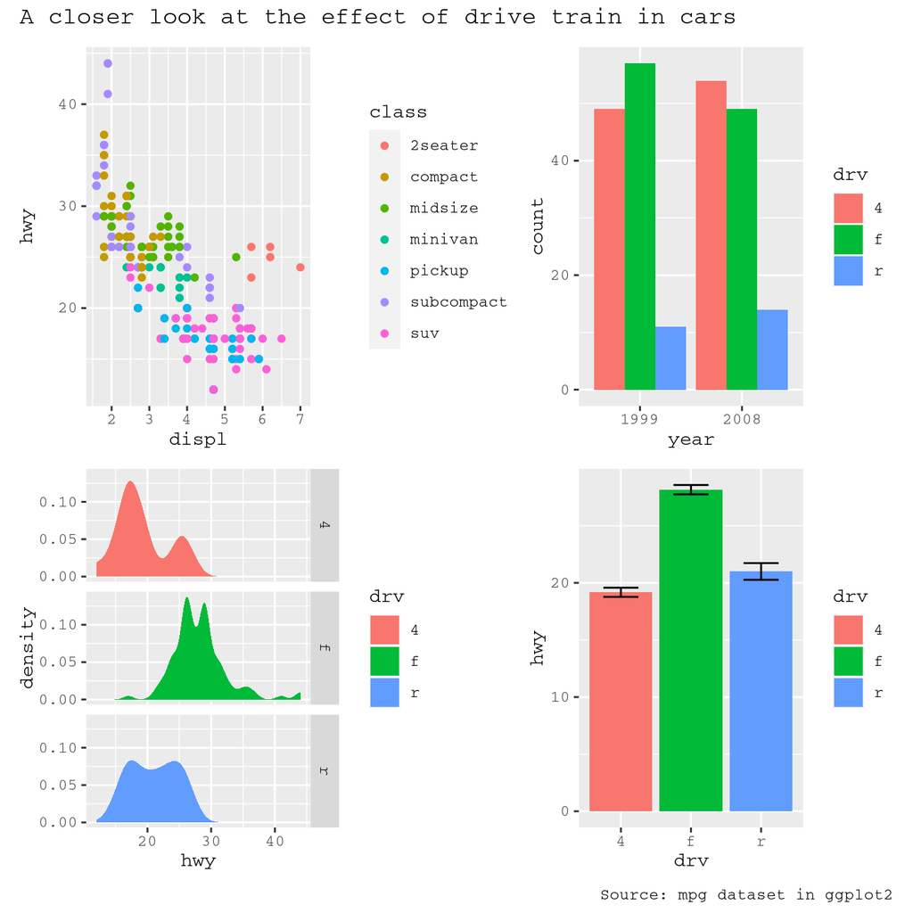

```r
p <- p1 + p2 + p3 + p4 + plot_annotation(
  title = "A closer look at the effect of drive train in cars",
  caption = "Source: mpg dataset in ggplot2"
)
p & theme_gray(base_family = "mono")
## p + theme_gray(base_family = "mono") 는 동작하지 않음
```

#### sub-title

`-` p1~p4 정의

```r
p1 <- ggplot(mpg) +
  geom_point(aes(x = displ, y = hwy, color = class))

p2 <- ggplot(mpg) +
  geom_bar(aes(x = as.character(year), fill = drv), position = "dodge") +
  labs(x = "year")

p3 <- ggplot(mpg) +
  geom_density(aes(x = hwy, fill = drv), colour = NA) +
  facet_grid(rows = vars(drv))

p4 <- ggplot(mpg) +
  stat_summary(aes(x = drv, y = hwy, fill = drv), geom = "col", fun.data = mean_se) +
  stat_summary(aes(x = drv, y = hwy), geom = "errorbar", fun.data = mean_se, width = 0.5)
```

`-` 그림준비

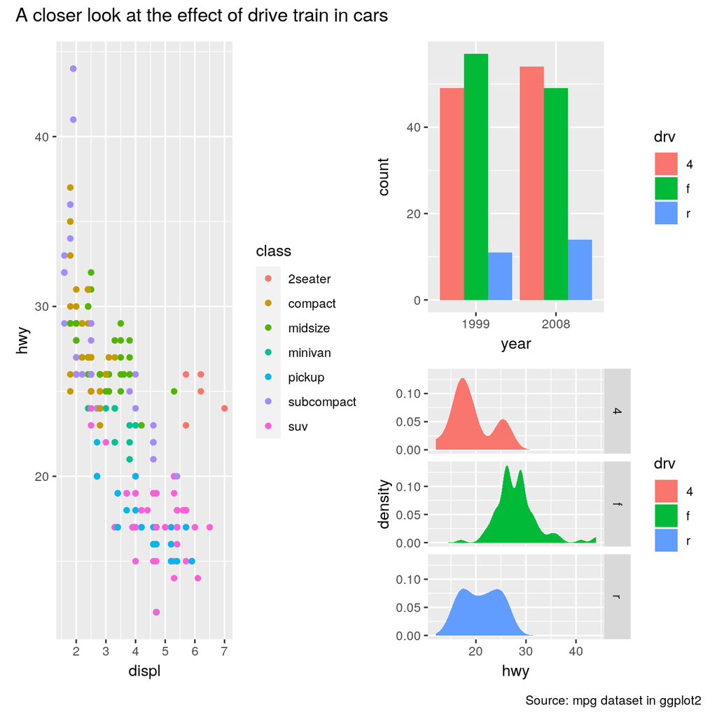

```r
p <- (p1 | (p2/p3)) + plot_annotation(
  title = "A closer look at the effect of drive train in cars",
  caption = "Source: mpg dataset in ggplot2"
)
p
```

`-` p[[1]], p[[2]] 확인

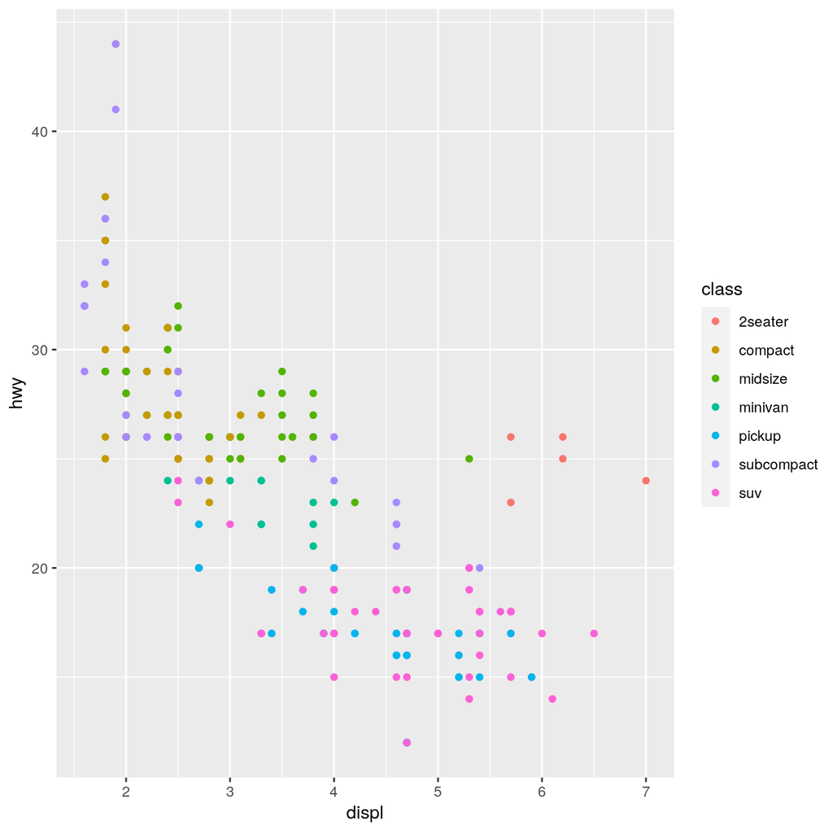

```r
p[[1]]
```

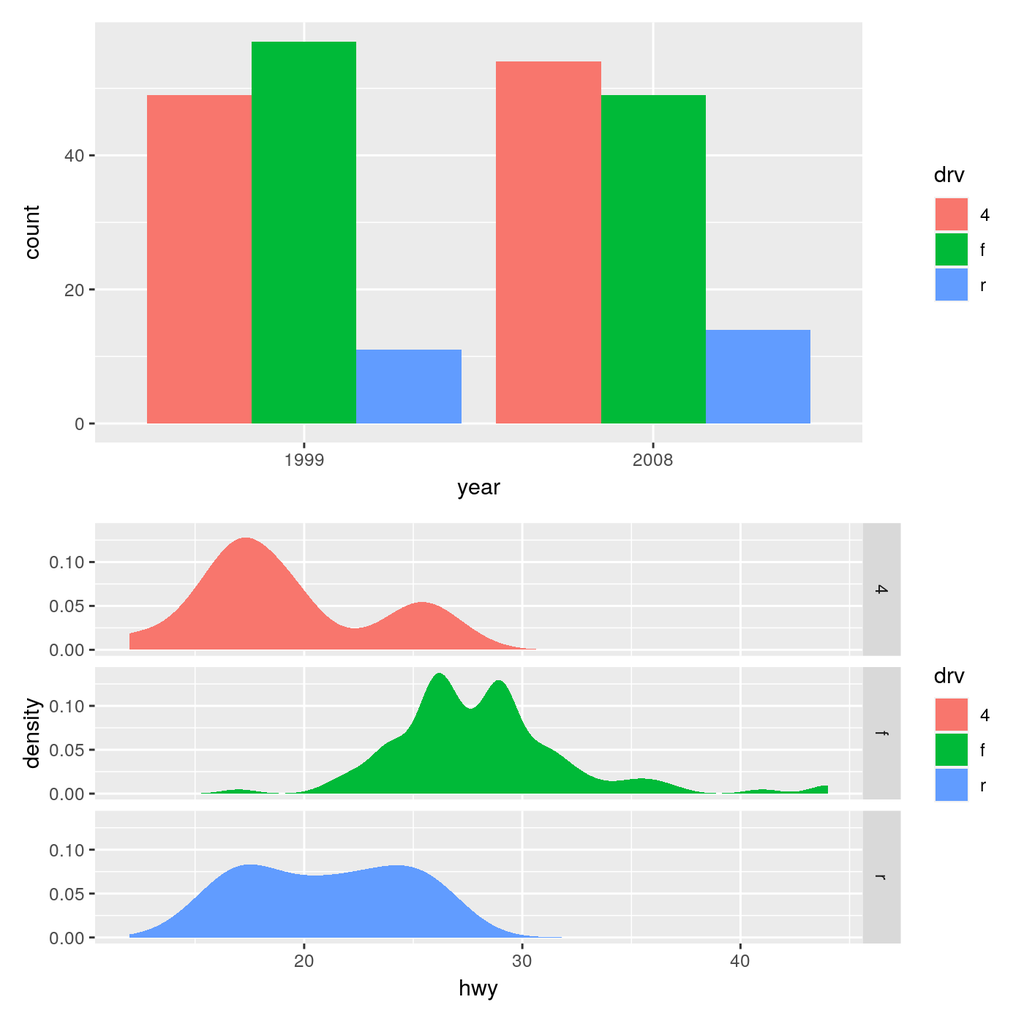

```r
p[[2]]
```

`-` tag_levels로 subtitle 만듬

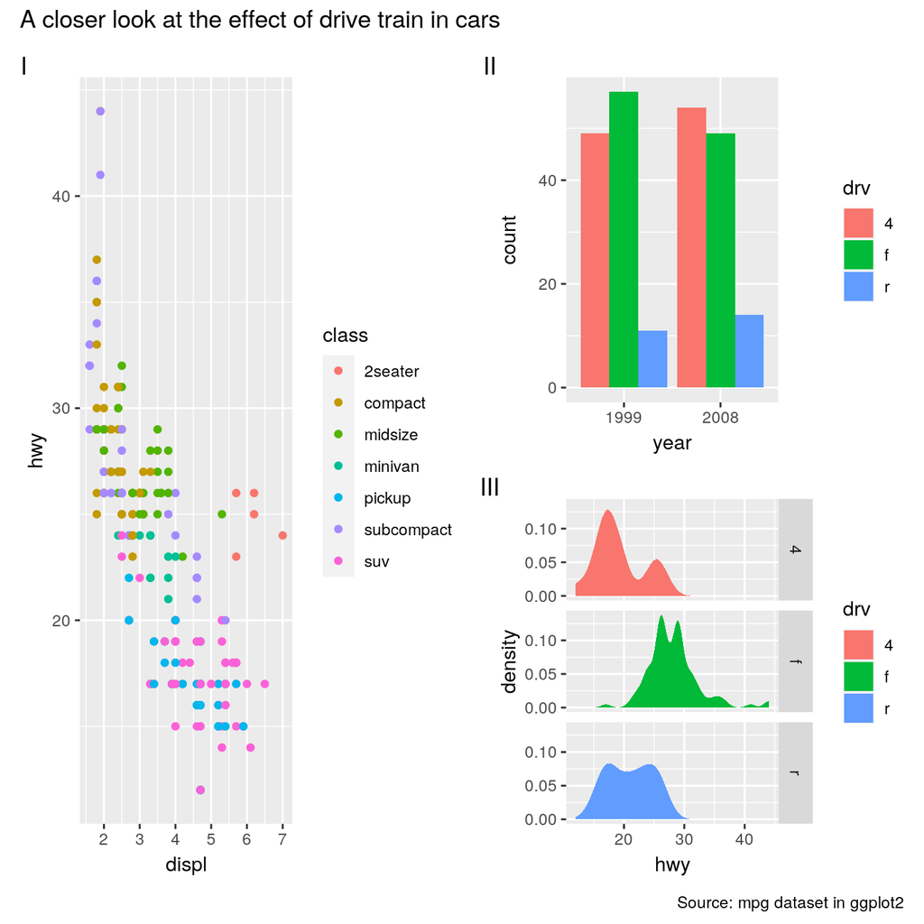

```r
p+plot_annotation(tag_levels = c("I"))
```

`-` tag_levels를 2단계로 함

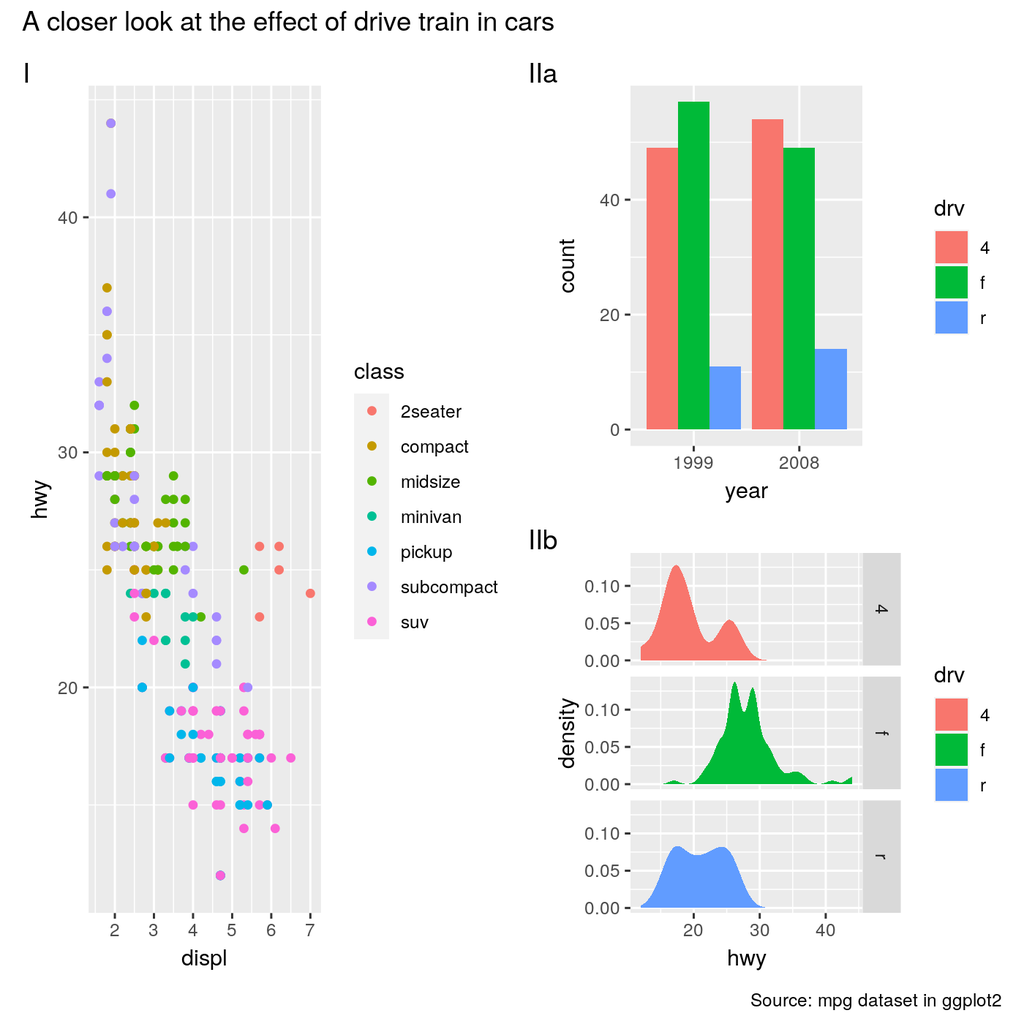

```r
p[[2]] <- p[[2]] + plot_layout(tag_level = "new")
p+plot_annotation(tag_levels = c("I","a"))
```

- 별로 유용한지 모르겠음

### plot 삽입

`-` p1~p4 정의

```r
p1 <- ggplot(mpg) +
  geom_point(aes(x = displ, y = hwy, color = class))

p2 <- ggplot(mpg) +
  geom_bar(aes(x = as.character(year), fill = drv), position = "dodge") +
  labs(x = "year")

p3 <- ggplot(mpg) +
  geom_density(aes(x = hwy, fill = drv), colour = NA) +
  facet_grid(rows = vars(drv))

p4 <- ggplot(mpg) +
  stat_summary(aes(x = drv, y = hwy, fill = drv), geom = "col", fun.data = mean_se) +
  stat_summary(aes(x = drv, y = hwy), geom = "errorbar", fun.data = mean_se, width = 0.5)
```

`-` 그림삽입1

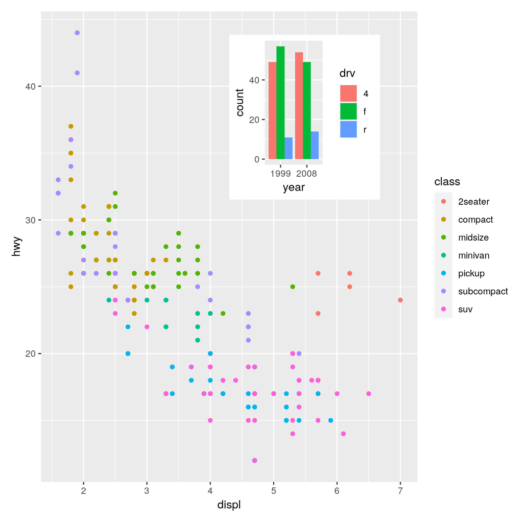

```r
p1 + inset_element(p2, left = 0.5, bottom = 0.6, right = 0.9, top = 0.95)
```

`-` 그림삽입2

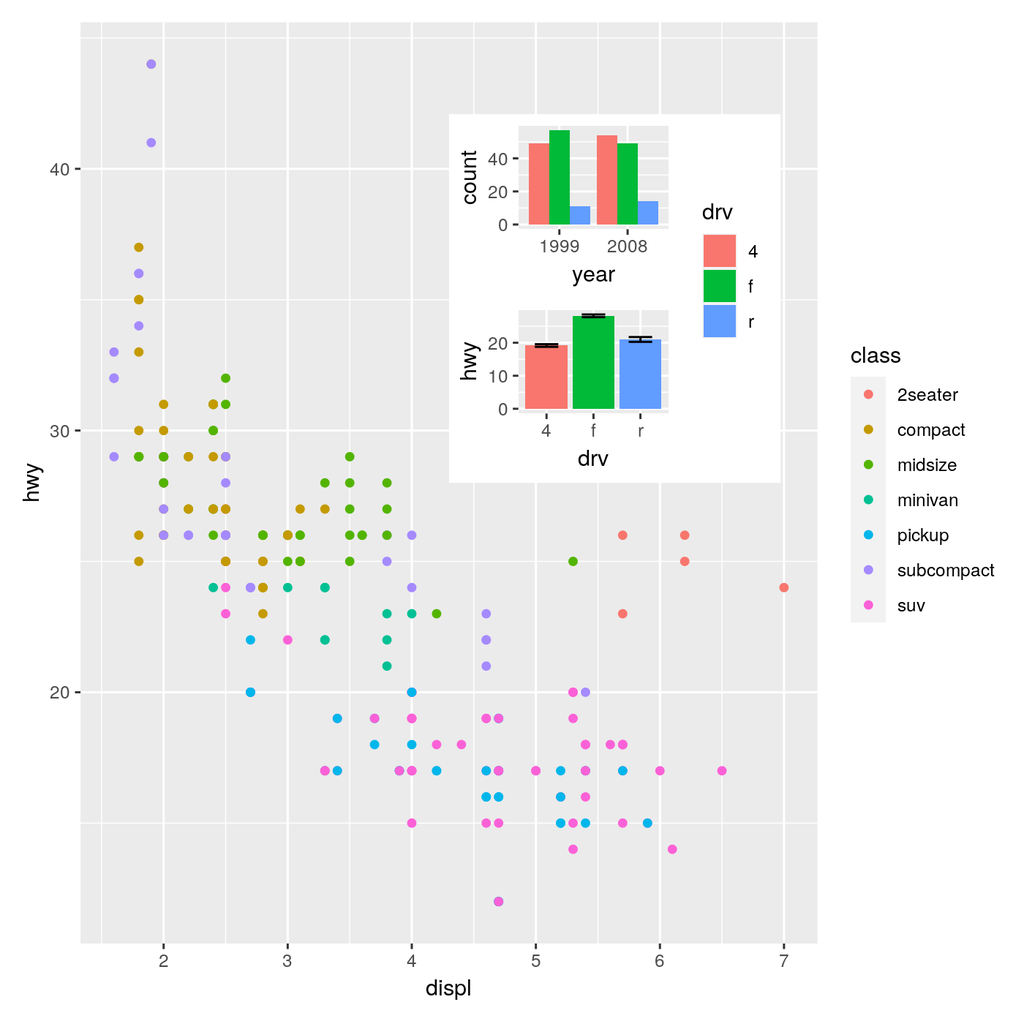

```r
p24 <- p2 / p4 + plot_layout(guides = "collect")
p1 + inset_element(p24, left = 0.5, bottom = 0.5, right = 0.95, top = 0.9)
```

`-` 그림삽입3

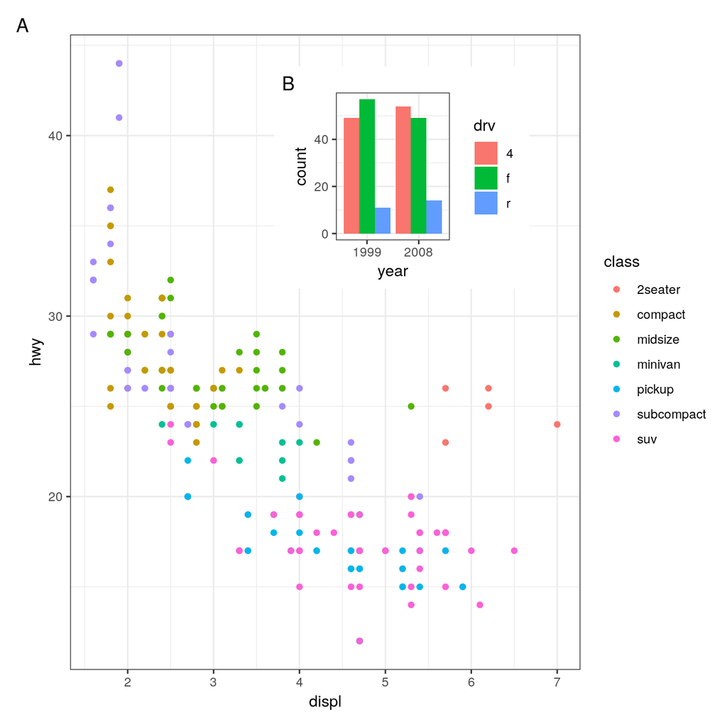

```r
p12 <- p1 + inset_element(p2, left = 0.4, bottom = 0.6, right = 0.9, top = 0.95) +
  plot_annotation(tag_levels = 'A')
p12 & theme_bw()
```